# KETO-CTA Study

An Audit with the Actual Data

John | The John & Calvin Podcast

## Dataset of Plaque Metrics

[Longitudinal Data From the KETO-CTA Study: Plaque Predicts Plaque, ApoB Does Not](https://www.jacc.org/doi/10.1016/j.jacadv.2025.101686)

Plaque Data released by organization funding the study:

https://citizensciencefoundation.org/keto-cta/

No cholesterol (ApoB), demographic or other clinical data

All code, figures, data, studies available at:

https://github.com/SloughJE/keto_cta_analysis_check

## Incorrect Figure 1B

**Figure 1B from Study**

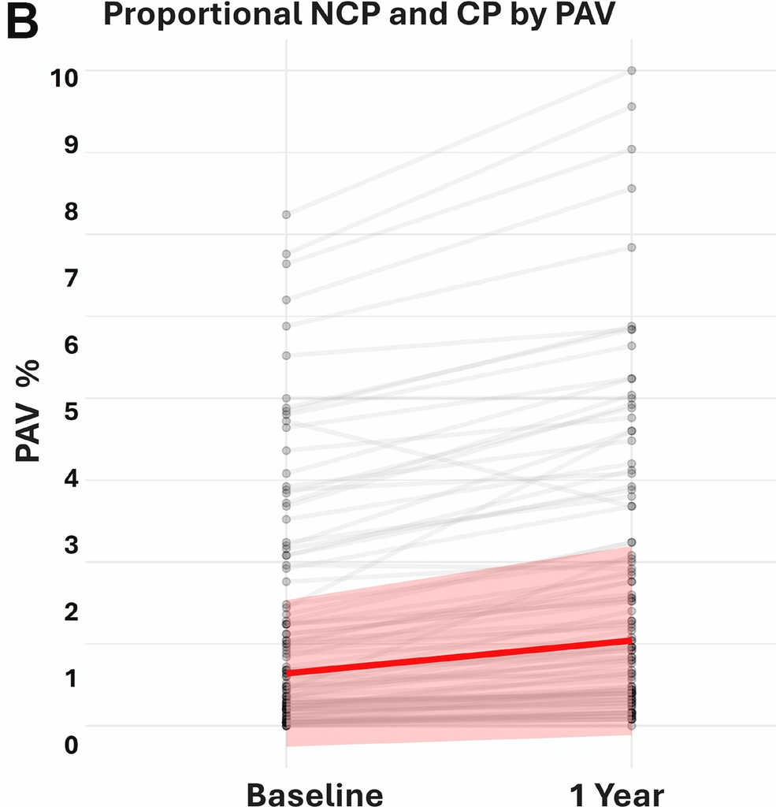

**Figure 1B from Data**

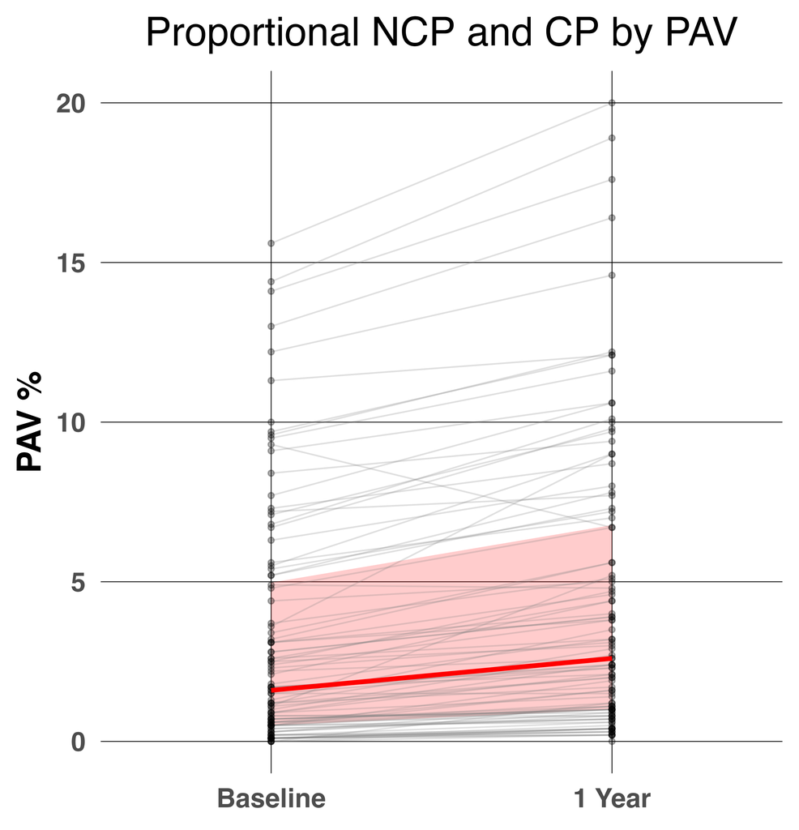

Individual Change in Plaque Volume

(B) The red line represents the median change (0.8%), and the shaded area represents the IQR (0.3%-1.7%).

## Incorrect Figure 1A

**Figure 1A from Study**

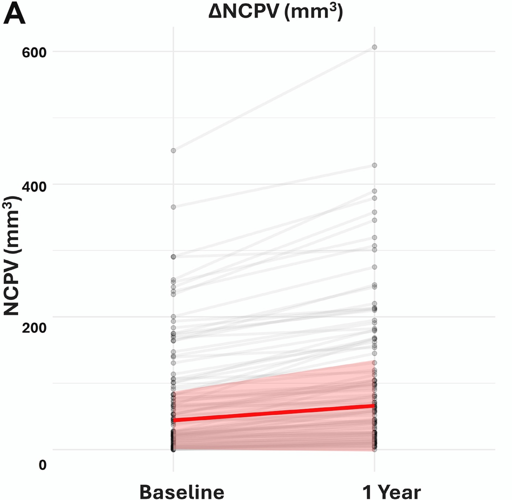

**Figure 1A from Data**

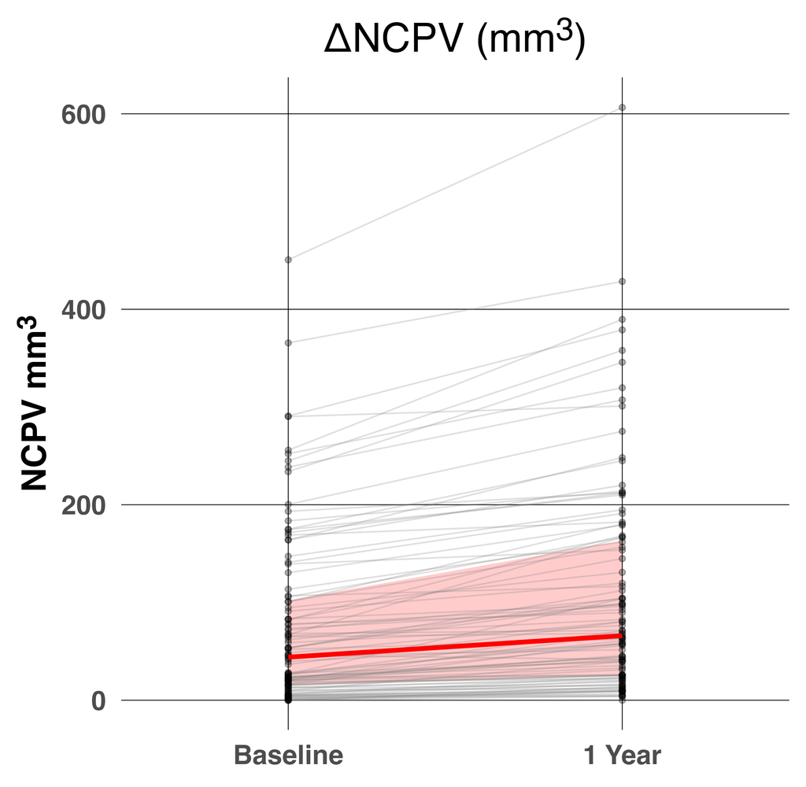

Individual Change in Plaque Volume

(A). The red line represents the median change (18.9 mm3), and the shaded area represents the IQR (9.3-47.0 mm3).

## Incorrect Figures 2D, 2E, 2F

**Figure 2F from Study**

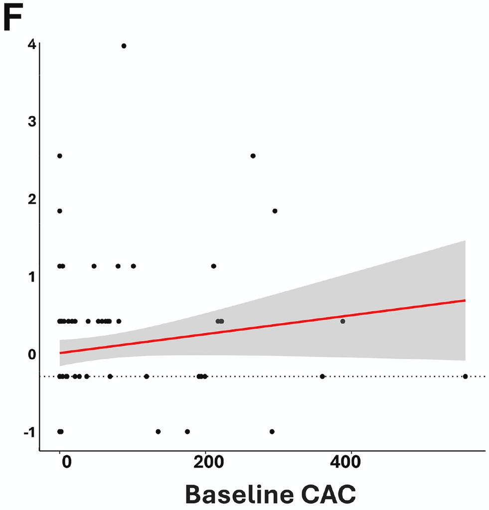

**Figure 2F from Data**

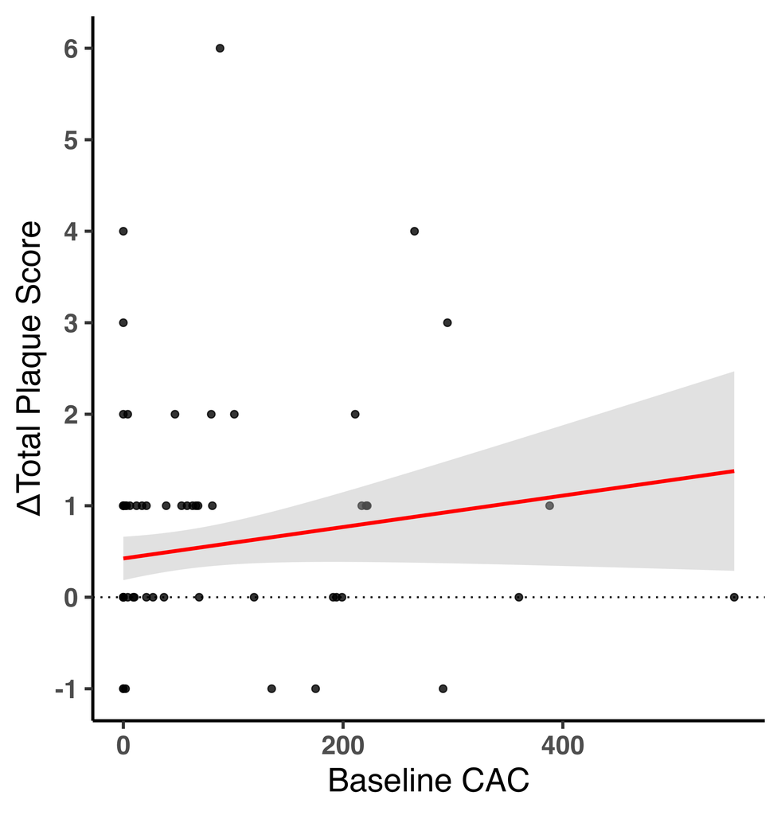

Changes in Total Plaque Score vs Coronary Artery Calcium

(C, F) Only CAC is associated with changes in NCPV and TPS. The regression line was fitted with the function “lm,” which regresses y~x, and the shaded area represents the standard error.

## Linear Model Assumptions

4 Simple Linear Regression Assumptions

3 are tested with data (in this situation)

- **Linearity**: between the predictor and the outcome
- **Constant variance** (homoscedasticity) of residuals
- **Normally distributed residuals**

These linear assumptions are **quantifiable** and **objectively testable**.

- If the assumptions don’t hold, statistical significance and uncertainty estimates aren’t trustworthy
- Results may be invalid

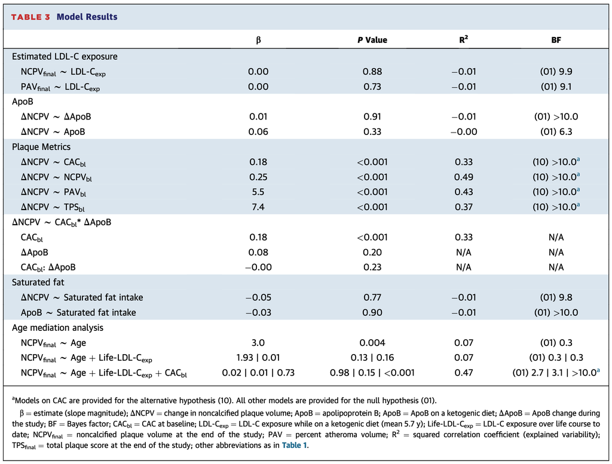

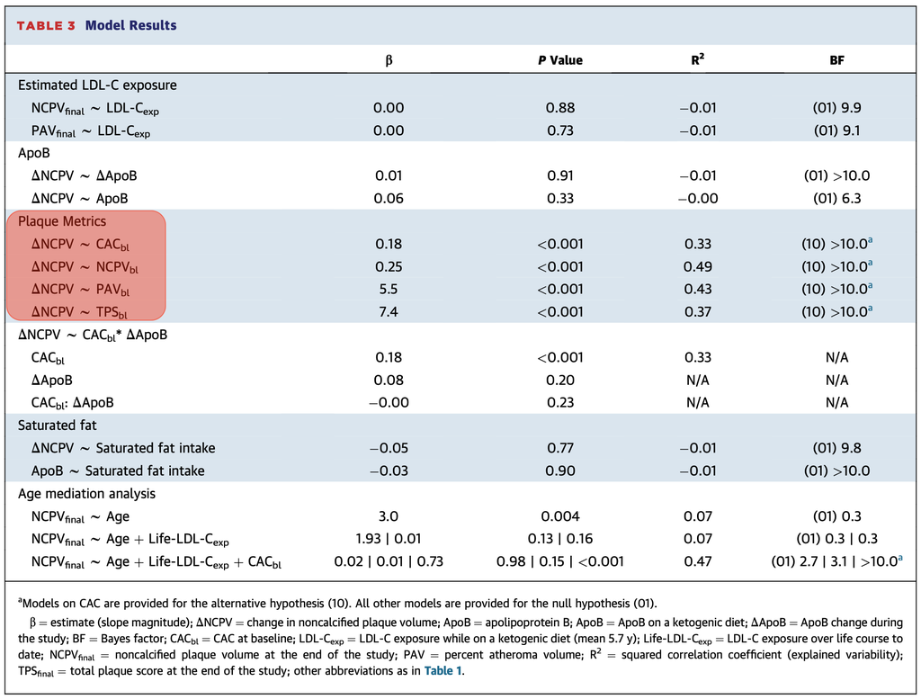

## LM Assumptions (claims vs tests)

> [“all linear model assumptions were corroborated with the R function `performance::check_model`.”](https://www.jacc.org/doi/10.1016/j.jacadv.2025.101686)

> - *Direct quote from the study*

Actual Linear Model Assumption Tests

| Model | β | Linearity | Constant Variance | Residual Normality |
| --- | --- | --- | --- | --- |
| **ΔNCPV ~ CAC<sub>bl</sub>** | β = 0.18 p = <0.001 | Violation p = 0.031 | Violation p = 0.001 | Violation p = <0.001 |
| **ΔNCPV ~ NCPV<sub>bl</sub>** | β = 0.25 p = <0.001 | OK p = 0.198 | Violation p = <0.001 | Violation p = <0.001 |
| **ΔNCPV ~ PAV<sub>bl</sub>** | β = 5.48 p = <0.001 | Borderline p = 0.050 | Violation p = <0.001 | Violation p = <0.001 |
| **ΔNCPV ~ TPS<sub>bl</sub>** | β = 7.37 p = <0.001 | OK p = 0.132 | Violation p = <0.001 | Violation p = 0.001 |

Objective tests show all 4 models failed at least 2 tests each.

### Letter to Editor and Response

> [“The validity of the regression models is also questionable. Despite claims of meeting assumptions, variables were reported using medians, suggesting non-normal distributions. Visual inspection of scatter plots shows clustering and no clear linear trends. Robust or nonparametric methods might have been more appropriate, and model diagnostics would improve transparency.”](https://www.jacc.org/doi/10.1016/j.jacadv.2025.101861)

> - *quote from letter to the editor*

> [“we are aware of the relevance of linear assumptions to obtain accurate estimators. Because residual plot evaluation can also be subjective, we followed their suggestion and reran all models with robust linear regression (using the `MASS::rlm` function in R version 4.4.3 [R Foundation]). While, as expected, there were small differences with the published estimates, all models using robust regression were consistent with what was reported.”](https://www.jacc.org/doi/10.1016/j.jacadv.2025.101862)

> - *quote from the reply to a letter to the editor*

> [“**residual plot evaluation can also be subjective**”](https://www.jacc.org/doi/10.1016/j.jacadv.2025.101862)

> - *quote from the reply to a letter to the editor*

> [“we are aware of the relevance of linear assumptions to obtain accurate estimators. Because residual plot evaluation can also be subjective, we followed their suggestion and reran all models with robust linear regression (using the `MASS::rlm` function in R version 4.4.3 [R Foundation]). While, as expected, there were small differences with the published estimates, all models using robust regression were consistent with what was reported.”](https://www.jacc.org/doi/10.1016/j.jacadv.2025.101862)

> - *quote from the reply to a letter to the editor*

### LM Assumptions: Objective Tests

- Calling residual plot evaluation “subjective” is evasive.
- Visual checks are interpretive, but these assumptions **objectively** testable with **quantifiable** methods.
- This is Statistics 101.
- “reran all models with robust linear regression…`MASS::rlm`”
- Robust Linear Regression mainly just down-weights outliers.
- Does not deal with non-linearity, heteroskedasticity and non-normality of residuals.

**`check_model` output**:

[figure not shown]

### Conclusions Without Supporting Models

> “**CONCLUSIONS** In lean metabolically healthy people on KD, neither **total exposure** nor changes in baseline levels of ApoB and LDL-C were associated with **changes in plaque**.”

> “there is no association between NCPV vs LDL-C or ApoB and TPS vs LDL-C or ApoB.”

[output not shown]

### Missing TPS Models and Results

> “**Results** Neither change in ApoB …, baseline ApoB, nor total LDL-C exposure … were associated with the change in noncalcified plaque volume (NCPV) or TPS.”

> “Neither … change in ApoB nor the ApoB level … were associated … with **TPS** (Figures 2D and 2E, **Table 3**).” - “changes in and baseline levels of ApoB were not associated with changes in NCPV or TPS”

Figures 2D–2F are Δ-TPS (outcome) panels (vs ΔApoB, ApoB, CAC_bl)

Table 3 Model Results has **no Δ-TPS** models

No Δ-TPS ~ LDL-C, LDL-C exposure, or ApoB model results anywhere.

### TPS association with CAC

“**CAC is associated with changes in NCPV and TPS**”

$\Delta \text{TPS} \sim \text{CAC}_{\text{baseline}}$

| β (95% CI) | P Value | R² adj |
| --- | --- | --- |
| 0.002 (-0.0004, 0.0038) | 0.11 | 0.016 |

**CAC is not associated with $\Delta$TPS**

**Figure 2F from Data**

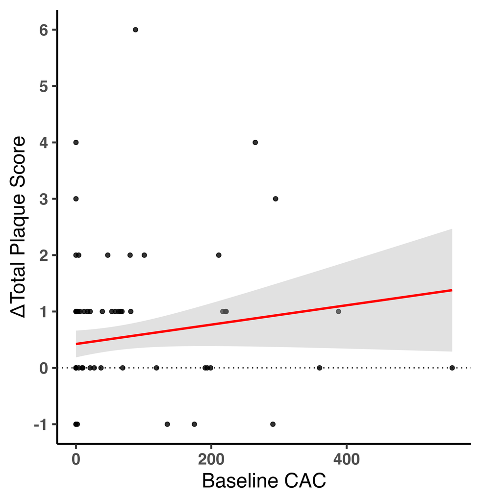

Changes in Total Plaque Score vs Coronary Artery Calcium

(C, F) Only **CAC is associated with changes in NCPV and TPS**. The regression line was fitted with the function “lm,” which regresses y~x, and the shaded area represents the standard error.

### Bayes Factor `rscale` is not Moderate

> “Bayes factors were calculated…with…an ~ `rscale value of 0.8` to contrast a **moderately informative** prior with a conservative distribution width (to allow for potential large effect sizes) due to the well-documented association between ApoB changes and coronary plaque changes.”

Calling rscale = 0.8 “moderately informative” is inaccurate.

[R package docs](https://search.r-project.org/CRAN/refmans/BayesFactor/html/regressionBF.html): **“medium”, “wide”, “ultrawide” = 0.354, 0.5, 0.707**

- `rscaleCont = 0.8` is **wider than “ultrawide”**
- substantial evidence needed to show a non-null effect
- Same r-scale apparently used for **all models**. No sensitivity analysis on r-scale.

> “the addition of Bayesian inference adds credence to finding that there is no association between NCPV vs LDL-C or ApoB and TPS vs LDL-C or ApoB”
- only “justification” for Bayesian modeling
- no indication of prespecification

### LDL-C Exposure Calculation

> “LDL-C exposure on a KD was calculated by summing the products of the reported days on a KD prior to study commencement and baseline LDL-C on a KD plus the study follow-up days by their final LDL-C.”

$$\text{LDL-C}_{\text{exp}}
=
Days_{\text{KD}}\cdot LDL_{\text{baseline}}
\;+\;
Days_{\text{follow-up}}\cdot LDL_{\text{final}}$$

- one baseline value for all pre-study Keto Diet time and one final value for all follow-up is a coarse simplification
- relies on recall of KD start
- standard AUC/time-weighted approach (need multiple measurements)
- limitation due to resources

### Lifetime LDL-C Formula Doesn’t Add Up

> “LDL-C exposure on a KD was calculated by summing the products of the reported days on a KD prior to study commencement and baseline LDL-C on a KD plus the study follow-up days by their final LDL-C.”

$$\text{LDL-C}_{\text{exp}}
=
Days_{\text{KD}}\cdot LDL_{\text{baseline}}
\;+\;
Days_{\text{follow-up}}\cdot LDL_{\text{final}}$$

> “Estimated lifelong LDL-C additionally included the product of age upon commencing a KD and pre-KD LDL-C.”

$$\text{Life-LDL-C}_{\text{exp}}
=
Days_{\text{KD}}\cdot LDL_{\text{baseline}}
\;+\;
Days_{\text{follow-up}}\cdot LDL_{\text{final}}
\;+\;
\boldsymbol{\big( Age_{\text{at-KD-start}}\cdot LDL_{\text{pre-KD}} \big)}$$

- **This equation is dimensionally inconsistent.**
- It adds days and age together. It’s like adding miles and inches.
- pre-KD term is down-scaled by ~365× relative to the day-based terms.
- any associations with outcomes are dominated by keto diet exposure.
- if they did convert age, “lifetime” exposure just reflects how old someone was at KD

### This isn’t an Age Mediation Analysis

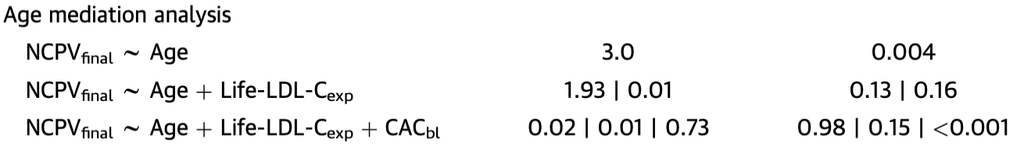

> “Estimated lifetime LDL-C exposure was only a significant predictor of final NCPV in the univariable analysis but lost significance when age was included as a covariate (Table 3). Both age and lifetime LDL-C exposure lost significance when baseline CAC was included in the model (Table 3).”

A [mediation](https://library.virginia.edu/data/articles/introduction-to-mediation-analysis) analysis is a specific statistical method that:

- tests how an exposure affects an outcome through a middle step (the *mediator*)
- estimates an indirect effect (through the mediator) and a direct effect (everything else).
- requires a pre-specified pathway and proper statistical testing (usually with CIs or bootstraps).

**This is not a mediation analysis**.

- No indirect effect was estimated or tested. No causal model specified.
- Age can’t be a mediator of LDL exposure (age isn’t caused by LDL); it’s a confounder.
- They only compared p-values after adding variables.

### This isn’t an Age Mediation Analysis

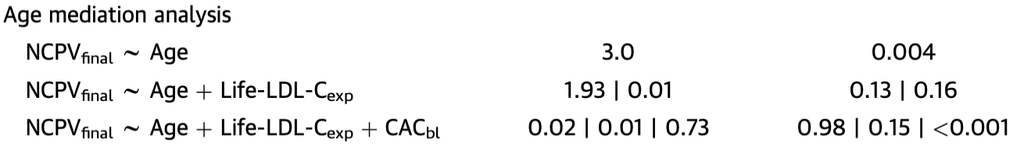

> “Estimated **lifetime LDL-C exposure** was only a **significant predictor of final NCPV** in the univariable analysis but lost significance when age was included as a covariate (Table 3). Both age and lifetime LDL-C exposure lost significance when baseline CAC was included in the model (Table 3).”

They ran (reported) three regressions with sequential covariate adjustment and concluded:

*after adjusting for baseline CAC, neither age nor lifetime LDL-C predicts NCPV_final.*

*- **CAC explains the association**; age / lifetime LDL-exposure don’t matter.*

“Loses significance” ≠ mediation. Collinearity since lifetime LDL-C embeds age.

Age is a common cause/proxy of both lifetime LDL-C exposure and NCPV. It’s a confounder, not a mediator.

Adding baseline CAC (a downstream variable) blocks the mediation pathway and biases effects.

**They did NOT report `NCPV_final ~ lifetime LDL-C exposure`.**

### Nonstandard Percent Change

> “The median change in NCPV was 18.9 mm3 (IQR: 9.3-47.0 mm³) and the median change in PAV was 0.8% (IQR: 0.3%-1.7%). Compared to baseline, these represent **a 43% and 50% change**, respectively.”

**Standard percent change:** $\operatorname{median}\!\left(\frac{NCPV_{1y}-NCPV_{bl}}{NCPV_{bl}}\right)\times 100\%$

“What was the typical relative change per subject?”

They computed a **ratio of median change to baseline median:** $\frac{\operatorname{median}(NCPV_{1y}-NCPV_{bl})}{\operatorname{median}(NCPV_{bl})}\times 100\%$

- NCPV: $18.9/44 \approx 43\%$; and PAV: $0.8/1.6 \approx 50\%$

**Standard percent change vs. reported ratio-of-medians:**

| Outcome | “ratio-of-medians” | Median % change | Mean % change |
| --- | --- | --- | --- |
| NCPV | 43% | 49.2% | 81.4% |
| PAV | 50% | 47.3% | 80.7% |

Likely chosen because some baselines were zero.

Their “percent change” metric is nonstandard and should be labeled and justified.

### Univariable Change Models Can Mislead

> “Linear models on the primary (NCPV) and secondary outcomes were univariable”

All conclusions based on independent univariable change score models

`Δ-NCPV ~ ApoB`; `Δ-NCPV ~ NCPV_baseline`

- Basic confounding unchecked (age, sex, BP)
- Δ-NCPV contains baseline NCPV, biasing associations (mathematical coupling)
- Δ results in less power, compounded noise
- ignores starting plaque
- baseline imbalance and shared correlates can increase, reduce, or even reverse associations

[Consensus](https://www.fharrell.com/post/errmed/#change-from-baseline) in [biostatistics](https://onlinelibrary.wiley.com/doi/10.1002/sim.2682): use [baseline-adjusted regression,](https://pubmed.ncbi.nlm.nih.gov/16526009/) [ANCOVA style model](https://pmc.ncbi.nlm.nih.gov/articles/PMC1121605): [follow-up](https://europepmc.org/article/pmc/pmc9557845) ~ baseline + covariates for analyses.

`NCPV_follow-up ~ NCPV_baseline + ApoB_baseline + age + sex`

### ANCOVA Answers Relevant Question

`ΔNCPV ~ ApoB_baseline` (unadjusted change score)

**Question**: Among all participants, is baseline ApoB associated with the raw change in plaque over 1 year, without accounting for where people started or other factors?

**Slope interpretation**: Average difference in change (mm³) per 1 mg/dL higher ApoB, unadjusted.

**Clinically limited**: Doesn’t condition on starting plaque, age, sex, BP; easily distorted by baseline differences and extra noise in change scores.  
It doesn’t tell an individual with given baseline/risk profile what their 1-year plaque will be.

`NCPV_follow-up ~ NCPV_baseline + ApoB_baseline + age + sex` (ANCOVA)

**Question**: Among people with the same starting plaque, age, and sex, do those with higher ApoB tend to have more plaque in 1 year?

**Slope interpretation**: Expected difference in 1-year NCPV (mm³) per 1 mg/dL higher ApoB, holding baseline NCPV and covariates fixed.

**Clinically relevant**: What a patient wants to know; “Given where I start and my risk factors, does higher ApoB mean more plaque next year, and by how much?”

### Univariable Models are not the Norm

CCTA plaque-progression studies — model types & links

[output not shown]

### The Norm: ANCOVA

- Adjusting for baseline with follow-up as outcome (ANCOVA) is considered the [preferred method](https://pmc.ncbi.nlm.nih.gov/articles/PMC1121605/)
- [“Whether the outcome is change score or post score, one should always adjust for baseline using analysis of covariance (ANCOVA)”](https://pmc.ncbi.nlm.nih.gov/articles/PMC6330413/): follow-up as outcome, baseline as covariate
- [Adjusting](https://pmc.ncbi.nlm.nih.gov/articles/PMC8345531/) for [baseline and confounders](https://pmc.ncbi.nlm.nih.gov/articles/PMC7382001/) is [standard practice](https://pmc.ncbi.nlm.nih.gov/articles/PMC2796339/) in studies on [plaque progression](https://pmc.ncbi.nlm.nih.gov/articles/PMC8374741/)
- Observational (pre–post) studies almost always include **baseline plaque** when modeling progression. Not doing so risks confounding and regression to the mean (baseline imbalance).
- In RCTs randomization handles bias on average, but ANCOVA still gives cleaner, more precise estimates; it’s the usual choice.
- Baseline adjustment with change scores (Δ)?
  - Better than not including it, ANCOVA still preferred
  - Compounds measurement error, noisier and more biased
- [The correlation between baseline score and post-intervention score, and its implications for statistical analysis](https://pmc.ncbi.nlm.nih.gov/articles/PMC6330413/) — Change or post, **adjust for baseline** (ANCOVA) to avoid bias.
- [Statistics notes: Analysing controlled trials with baseline and follow up measurements](https://pmc.ncbi.nlm.nih.gov/articles/PMC1121605/) — **ANCOVA** is the **preferred** general approach; more powerful/robust than Δ alone.
- [Analyses of “change scores” do not estimate causal effects in observational data](https://pmc.ncbi.nlm.nih.gov/articles/PMC9557845/) — Change scores do **not** estimate causal effects in observational settings.

### ΔNCPV vs Follow-up NCPV

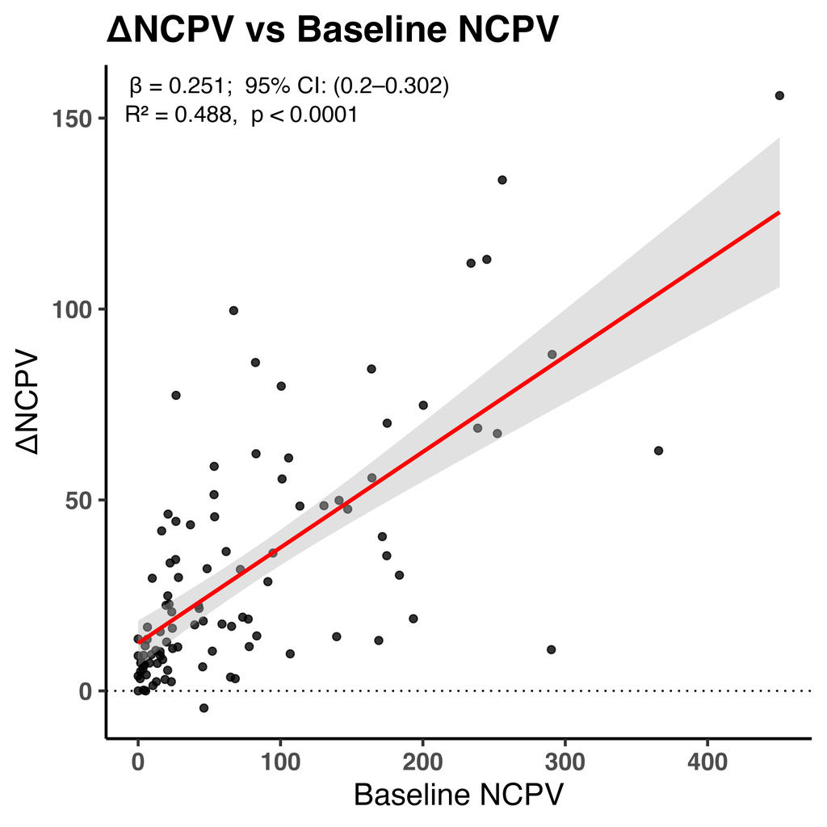

| β (95% CI) | P Value | R² adj |
| --- | --- | --- |
| 0.251 (0.200, 0.302) | <0.001 | 0.488 |

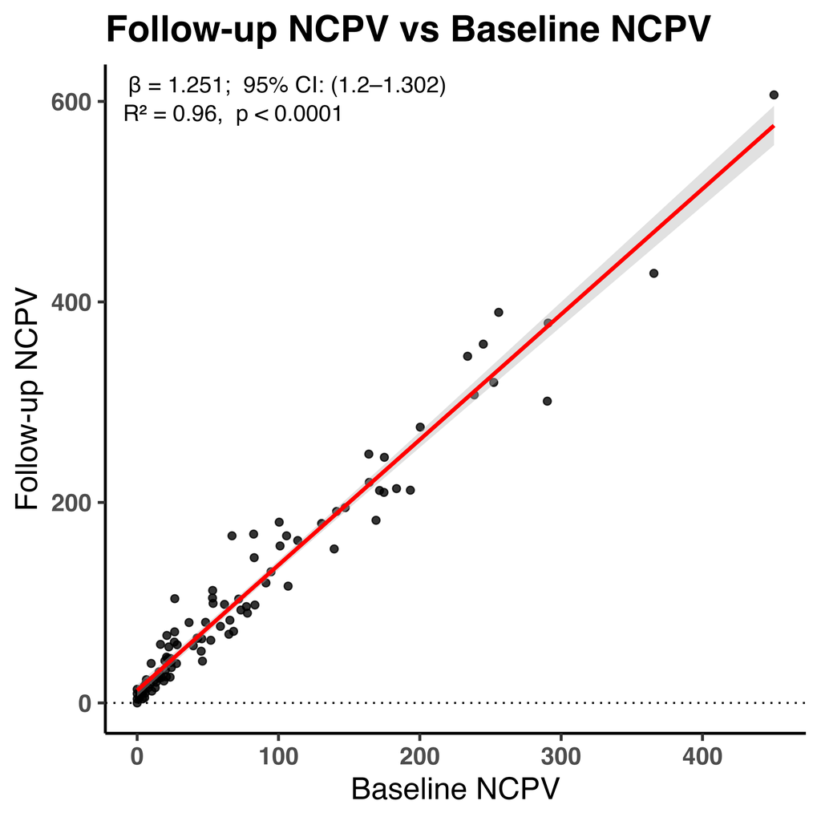

| β (95% CI) | P Value | R² adj |
| --- | --- | --- |
| 1.251 (1.200, 1.302) | <0.001 | 0.960 |

### ΔNCPV vs Follow-up NCPV

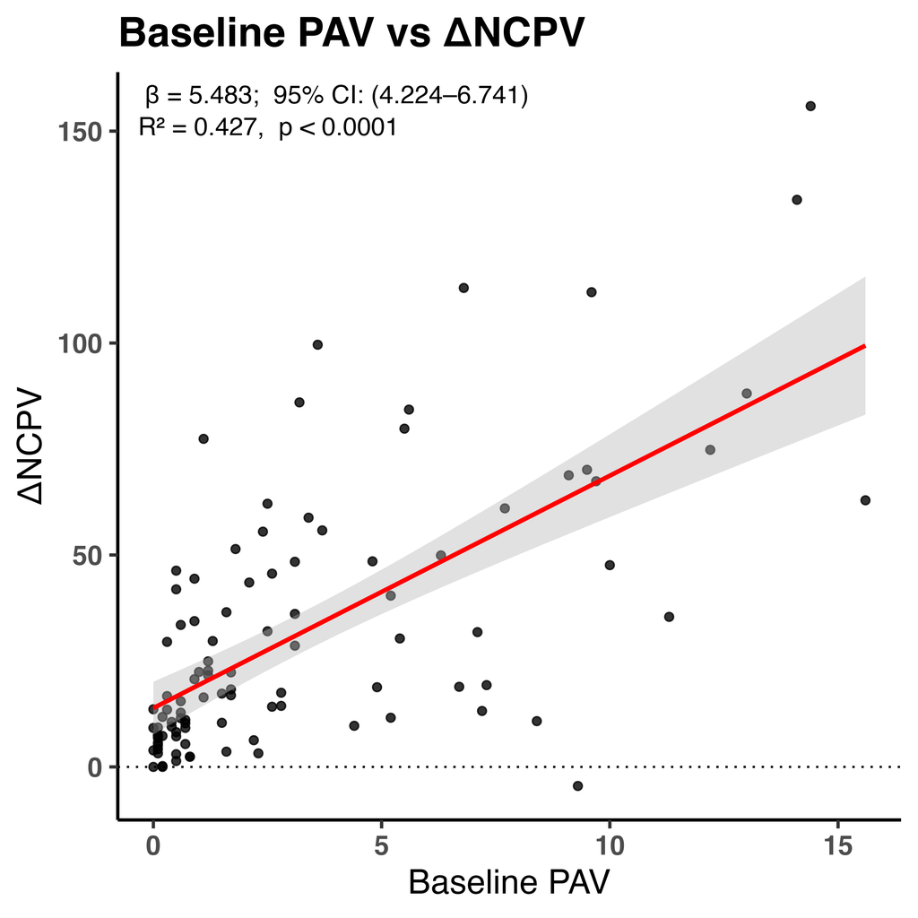

| β (95% CI) | P Value | R² adj |
| --- | --- | --- |
| 5.483 (4.224, 6.741) | <0.001 | 0.427 |

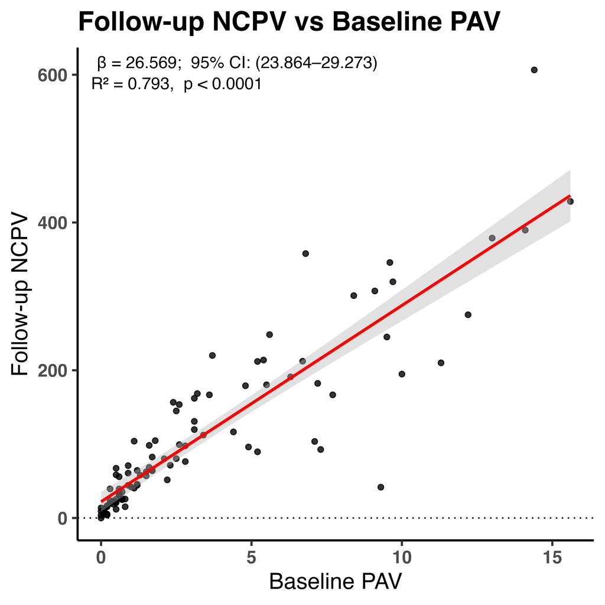

| β (95% CI) | P Value | R² adj |
| --- | --- | --- |
| 26.569 (23.864, 29.273) | <0.001 | 0.793 |

### ΔNCPV vs Follow-up NCPV

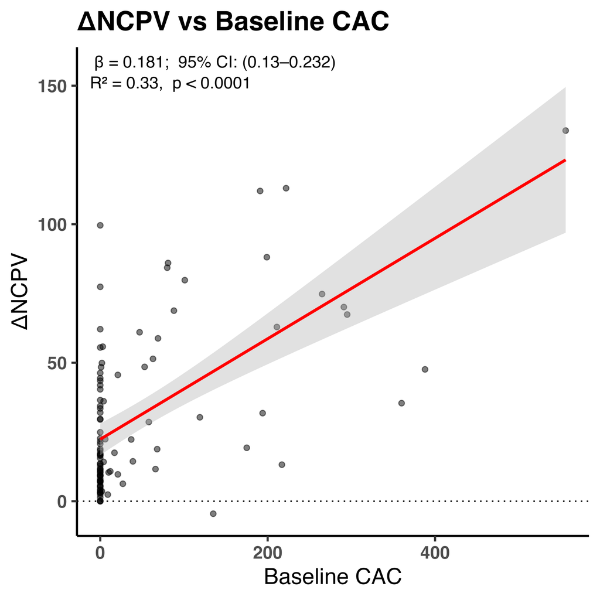

| β (95% CI) | P Value | R² adj |
| --- | --- | --- |
| 0.181 (0.130, 0.232) | <0.001 | 0.330 |

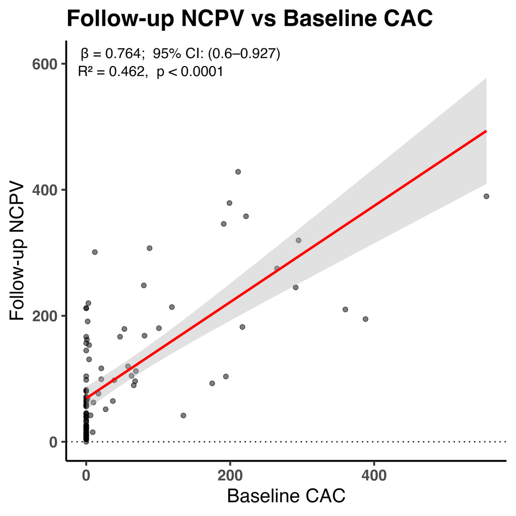

| β (95% CI) | P Value | R² adj |
| --- | --- | --- |
| 0.764 (0.600, 0.927) | <0.001 | 0.462 |

### Low R² = No Association!

But consider the [Partial R²](https://online.stat.psu.edu/stat462/node/138/)

`NCPV_follow-up ~ NCPV_baseline + ApoB`

- R² is the **fraction of total** variance explained by the **model**
- **Baseline R²**: % of variation explained baseline-only model, very high due to serial (auto)correlation
- **Partial R²**: % of the **remaining** variation explained by another covariate(s) (e.g., ApoB)

If baseline explains a lot, a small R² can still be a large share of what’s explainable beyond baseline.

- **Clinical ≠ high R²**: small effects add up over time and can still push patients past treatment thresholds and risk classification
- **Baseline R² ≈ 0.96:** 96% of follow-up NCPV variance is explained by **baseline NCPV**.
- **Residual R² after baseline: 4%** (for risk factors + measurement error + noise)
- **ApoB effect:** ΔR² ≈ 0.02 ⇒ Partial R² (ApoB | baseline) = 0.02 / 0.04 = 0.50
- ApoB explains 50% of the variance remaining after baseline.

“Plaque predicts plaque; ApoB does not” is a consequence of study design and model choice.

### R² metrics are seldom shown here

**Total/adjusted/partial R²:** common in simple linear models; not standard for more advanced models

There isn’t one standard R² (beyond ordinary linear regression)

- **Model dependence & collinearity:** partial R² unstable.
- **Small samples:** partial R² can be very noisy
- **Mixed model families:** GLM/mixed/hurdle lack a single standard R²
- **Plaque progression convention:** report $\beta$/OR with 95% CI and p-values.
- **Clinical interpretability:** “Δ outcome per 10 mg/dL ApoB” (not R²)

**Example:** Each 10 mg/dL higher ApoB is associated with a **+0.25 percentage-point** increase in plaque progression.

In this study, models violate OLS assumptions: R² can be high or low for the wrong reasons, misrepresenting model adequacy.

## Weakest model choice

- Among reasonable ways to test an ApoB~plaque association
  - with two timepoints, with this dataset
- ΔNCPV ∼ ApoB is the **weakest** plausible choice

$\Delta$NCPV ~ $\Delta$ApoB $\Delta$NCPV ~ ApoB

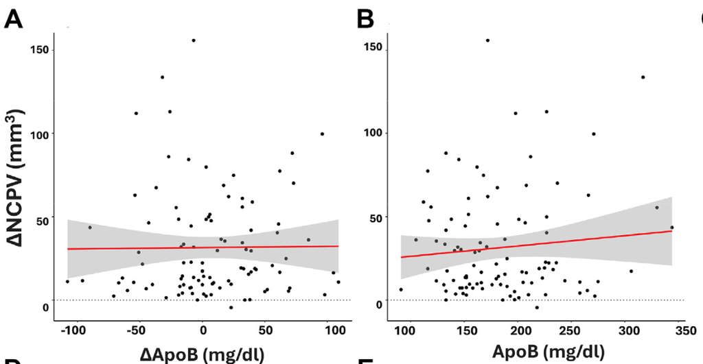

$\Delta$NCPV ~ $\Delta$ApoB: $\beta$ = 0.01, P Value = 0.91 $\Delta$NCPV ~ ApoB: **$\beta$ = 0.06**, P Value = 0.33

“changes in and baseline levels of ApoB were not associated with changes in NCPV”

- Claim of “no association” is overstated.
- Slope of $\beta$ = 0.06 still allows clinically non-trivial increases.
- Wide uncertainty? effects compatible with zero or clinically meaningful increases.
- Correct interpretation: inconclusive, not null.
- They do not report CI of $\beta$.

# Conclusions

1. Claims and charts contradict the data.
2. Multiple conclusions lack supporting analyses/results.
3. Some metrics are nonstandard or conceptually unsound.
4. “Assumptions corroborated”.  
   **— FALSE**. Model assumptions were violated.
5. The model results are invalid.
6. Proper and relevant analysis is baseline-adjusted ANCOVA.

**Miscellaneous issues**

| Location | Study Text | Issue |
| --- | --- | --- |
| **Figure 1 caption** | “…the shaded area represents the IQR (9.3-47.0 mm³)…” | **Imprecise.** The quoted IQR is the ΔNCPV IQR; shaded band is **25th–75th percentile band** at baseline and 1-year. |
| **Figures 2D–F Caption** | “(D to F) Change in ApoB, baseline ApoB, and baseline CAC vs **NCPV**.” | Axes/legend appear to be **TPS**, not NCPV → **label/data mismatch** |
| **Table 3 caption** | “R² = squared correlation coefficient (explained variability).” | Reports **negative values**, must be adjusted R² |
| **Table 3** | β = 0.18 | No reporting of CIs for β. |
| **KD Duration** Table 1 vs Table 3 | KD duration mean **1,642.7 days (≈4.5 y)** vs caption “LDL-C exposure … **mean 5.7 y**.” | **Inconsistent durations.** |
| **KD Duration** Abstract vs Table 1 | LDL-C exposure median **1,302 d (984–1,754)** vs KD duration median **1,427 d (1,002–1,938)**. | Metrics conflated. **exposure should be in units** like **mg/dL·days**, not days. |
| **Table 1 (Total cholesterol)** | Median **338**, IQR **(301–337)**. | **Impossible IQR** (Q3 < median) |
| **Follow-up Characteristics?** | Baseline table provided. | No follow-up characteristics table. ApoB significantly changed in 1 year. Did LDL? Are participants still “LMHR”? |
| **multiple** | “changes in baseline levels” | Baseline doesn’t change. |
| **Software statement** | “using R 4.0.3 (2020)… with the last available version for Sept 2024.” | Unclear what version was used. |
| Central Illustration | shows $\Delta$TPS ~ ApoB as main chart | Why? Not primary outcome. TPS model results not reported |
| Central Illustration (quote) | “Neither total exposure nor changes in baseline levels of ApoB and mg/dL were associated with changes in plaque. Conversely, baseline plaque but ApoB was not associated…” | Incoherent/grammatical errors |
| Main text (Results/Discussion) | “…baseline values magnify their **percentual** changes…” | percent change or percentage-point change |
| “Prediction” vs “Association | Study interchangably uses Prediction and Association | Prediction ≠ Association in statistics. Prediction needs out-of-sample validation |
| Change on Change Regressions | $\Delta$NVPC ~ $\Delta$ApoB | I cannot understand why they would even test this. |

### Preprint vs Published: What Changed

Pre-print title: **Plaque Begets Plaque, ApoB Does Not; Longitudinal Data From the KETO-CTA Trial**

Published title: **Longitudinal Data From the KETO-CTA Study; Plaque Predicts Plaque, ApoB Does Not**

In text: find and replace ‘**begets**’ with ‘**predicts**’.

Description of main figure, and primary outcome:

“Most participants presented with stable NCPV (Figures 1A and 1B), with 1 participant exhibiting a decrease in NCPV (Figures 2A to 2C) and 6 participants showing decreases in TPS scores over 1 year”

Removed and replaced with:

“The median change in NCPV was 18.9 mm3 (IQR: 9.3-47.0 mm3) and the median change in PAV was 0.8% (IQR: 0.3%-1.7%). Compared to baseline, these represent a **43% and 50% change**, respectively.”

In CONCLUSIONS section: “**In an exploratory analysis,** changes in and baseline levels of ApoB were not associated with changes in NCPV or TPS…”

“exploratory” added in published version. Only mention in entire paper.

Table 1 median (Q1–Q3) PAV at baseline changed from 1.25% (0.5–3.6) to 1.6% (0.5–4.9).

Record of pre-print is unavailable. All links go to new version. It is available [here](https://github.com/SloughJE/keto_cta_analysis_check/tree/main/papers).

# Appendix: Plaque Metrics

Baseline, follow-up, and paired change in plaque metrics at 1 year

| Metric | N<sup>1</sup> | Median (Q1–Q3) Baseline | Median (Q1–Q3) Follow-up | Median (Q1–Q3) Change<sup>2</sup> | Mean ± SD Baseline | Mean ± SD Follow-up | Mean ± SD Change<sup>2</sup> |
| --- | --- | --- | --- | --- | --- | --- | --- |
| Noncalcified plaque volume (mm³) | 100 | 44.0 (15.5–102.2) | 66.0 (25.2–163.2) | 18.8 (9.3–46.6) | 75.9 ± 88.3 | 107.4 ± 112.7 | 31.5 ± 31.5 |
| Coronary artery calcium score | 100 | 0.0 (0.0–54.2) | 0.0 (0.0–56.0) | 0.0 (0.0–5.0) | 50.3 ± 100.9 | 58.8 ± 120.4 | 8.5 ± 25.5 |
| Percent atheroma volume (%) | 100 | 1.6 (0.5–5.0) | 2.6 (1.0–6.8) | 0.8 (0.3–1.7) | 3.2 ± 3.8 | 4.4 ± 4.6 | 1.2 ± 1.2 |
| Total plaque score | 100 | 0.0 (0.0–2.2) | 1.0 (0.0–3.0) | 0.0 (0.0–1.0) | 1.7 ± 2.6 | 2.2 ± 3.0 | 0.5 ± 1.1 |
| Calcified plaque volume (mm³) | 100 | 0.3 (0.0–19.8) | 0.9 (0.0–24.2) | 0.5 (0.0–4.2) | 18.7 ± 37.4 | 22.7 ± 42.5 | 4.0 ± 7.4 |

<sup>1</sup> N = number of paired scans per metric.  
<sup>2</sup> Change = follow-up − baseline, summarized across participants.

Relative percent change from baseline to follow-up in plaque metrics at 1 year

| Metric | N (nonzero baseline)<sup>2</sup> | Percent change from baseline<sup>1</sup> Median (Q1–Q3) | Percent change from baseline<sup>1</sup> Mean ± SD |
| --- | --- | --- | --- |
| Noncalcified plaque volume (mm³) | 96 | 49.2 (26.0–104.4) | 81.4 ± 85.5 |
| Coronary artery calcium score | 43 | 15.6 (1.8–45.7) | 23.4 ± 56.6 |
| Percent atheroma volume (%) | 96 | 47.3 (25.9–100.0) | 80.7 ± 86.3 |
| Total plaque score | 47 | 25.0 (0.0–50.0) | 33.0 ± 77.4 |
| Calcified plaque volume (mm³) | 56 | 25.9 (10.8–64.7) | 60.9 ± 104.2 |

<sup>1</sup> Percent change = (follow-up − baseline) / baseline × 100; calculated per participant and summarized across participants.  
<sup>2</sup> N counts participants with a nonzero baseline for the metric.

Zeros, incidence (0→>0), and resolution (>0→0) by metric

| Metric | N | Baseline = 0 | Follow-up = 0 | 0 → >0 | >0 → 0 |
| --- | --- | --- | --- | --- | --- |
| Noncalcified plaque volume (mm³) | 100 | 4 | 1 | 3 | 0 |
| Coronary artery calcium score | 100 | 57 | 54 | 6 | 3 |
| Percent atheroma volume (%) | 100 | 4 | 1 | 3 | 0 |
| Total plaque score | 100 | 53 | 46 | 10 | 3 |
| Calcified plaque volume (mm³) | 100 | 44 | 27 | 18 | 1 |

Percent change from baseline to follow-up: medians and trimmed mean

| Metric | N<sup>2</sup> | N baseline > 0<sup>2</sup> | Median (Q1–Q3) % change<sup>1</sup> Overall (offset) | Median (Q1–Q3) % change<sup>1</sup> Baseline > 0 | Trimmed mean, 10%<sup>3</sup> |  |
| --- | --- | --- | --- | --- | --- | --- |
| Noncalcified plaque volume (mm³) | 100 | 96 | 44.9 (23.7–77.8) | 49.2 (26.0–104.4) |  | 51.0 |
| Coronary artery calcium score | 100 | 43 | 0.0 (0.0–13.4) | 15.6 (1.8–45.7) | 5.1 |  |
| Percent atheroma volume (%) | 100 | 96 | 33.3 (19.9–56.3) | 47.3 (25.9–100.0) | 37.8 |  |
| Total plaque score | 100 | 47 | 0.0 (0.0–14.3) | 25.0 (0.0–50.0) | 5.0 |  |
| Calcified plaque volume (mm³) | 100 | 56 | 4.1 (0.0–18.1) | 25.9 (10.8–64.7) | 9.1 |  |

<sup>1</sup> Overall % change = ((follow-up + c)/(baseline + c) - 1) × 100. BL>0 % change = ((follow-up - baseline)/baseline) × 100. c = 0.5 × the 5th percentile of non-zero values across visits for that metric, with floors: percentages 0.5; CAC 10; volumes 5. Positive values indicate increase vs baseline; negative indicate decrease.  
<sup>2</sup> N = paired participants; N baseline > 0 = number with nonzero baseline.  
<sup>3</sup> Trimmed mean removes 10% from each tail before averaging; computed on the Overall (offset) % change.

[figure not shown]

[Plaque Metrics Charts](https://github.com/SloughJE/keto_cta_analysis_check/tree/main/figures/plots_plaque_metrics/)

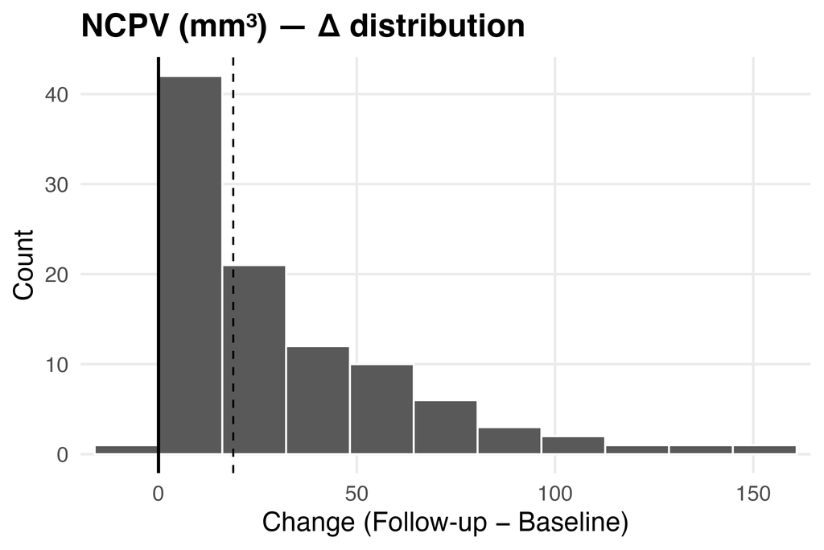

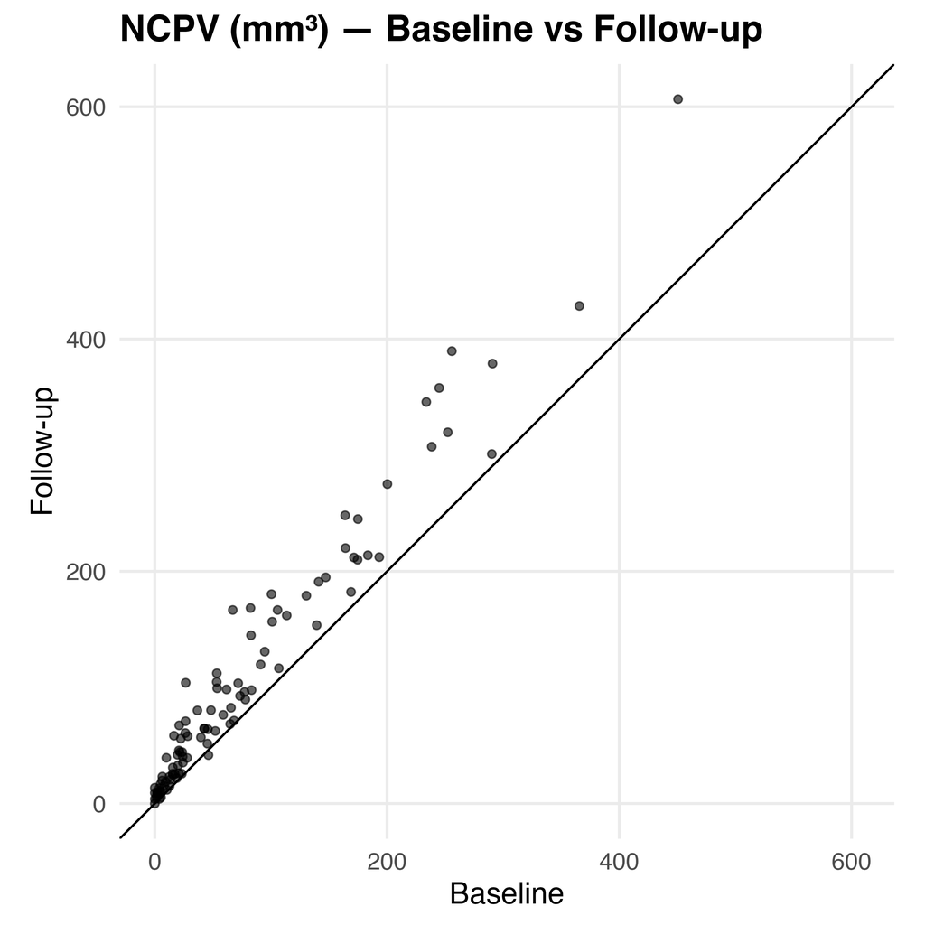

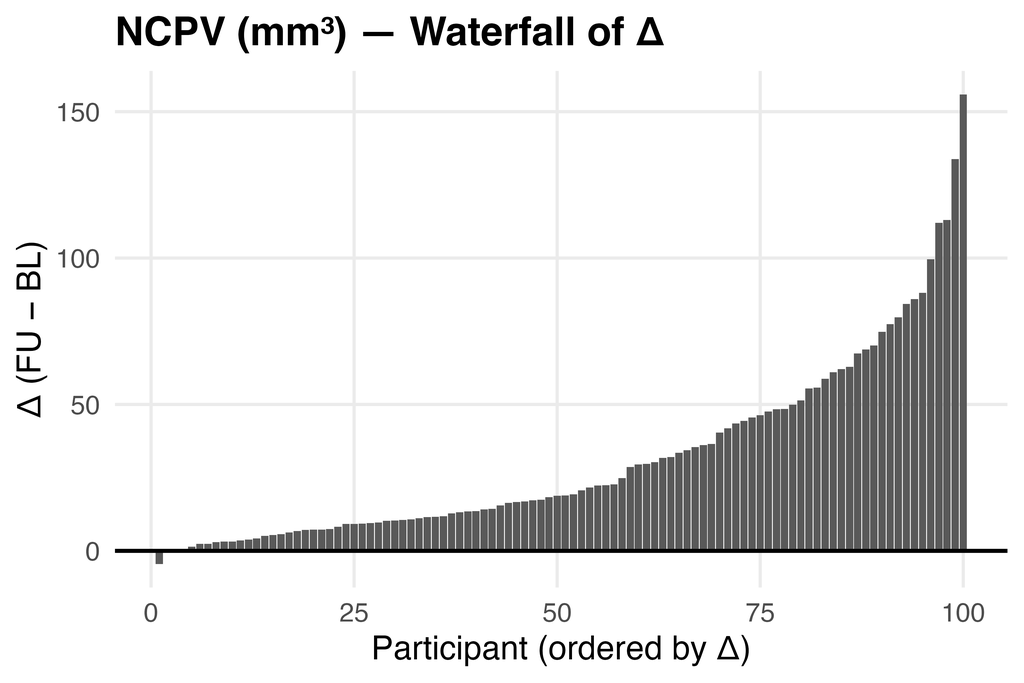

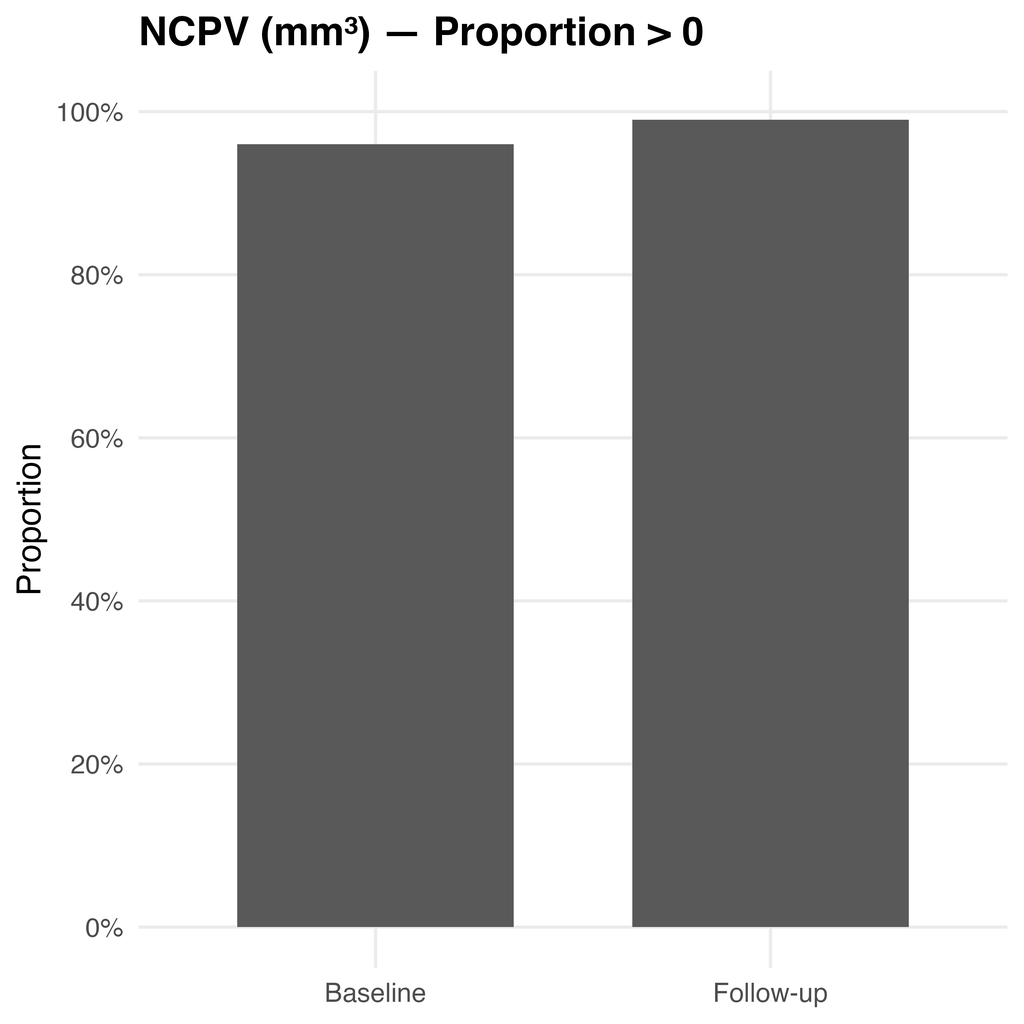

Plaque Baseline and Follow-up metrics are **highly correlated**

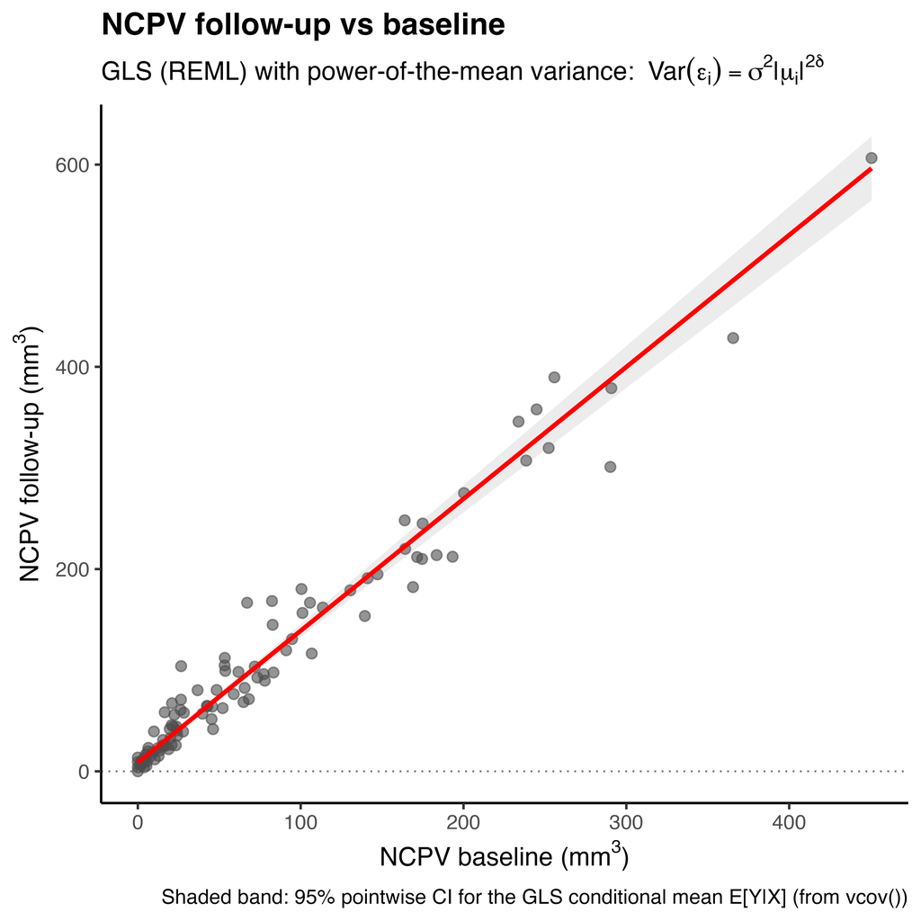

Follow-up NCPV was modeled as a linear function of baseline NCPV using generalized least squares (GLS): $Y_i=\beta_0+\beta_1 X_i+\varepsilon_i$, with a power-of-the-mean residual variance $\operatorname{Var}(\varepsilon_i)=\sigma^2\lvert\mu_i\rvert^{2\delta}$ (`nlme` `varPower`), where $\mu_i=\mathbb{E}[Y_i\mid X_i]$.

Candidate variance structures (same fixed effects) were compared by likelihood-ratio tests under maximum likelihood.

The selected structure was refit by restricted maximum likelihood (REML) for parameter estimates and uncertainty.

Pointwise 95% confidence bands for $\mathbb{E}[Y\mid X]$ were obtained from the model-based covariance of the fitted mean.

**Fit statistics (REML):** AIC = 874.15; BIC = 884.49; $\log L=-433.08$

**Variance function:** $\hat\delta=0.526$ (95% CI 0.357–0.695)

**Residual SD:** $2.097$ (df = 98; 95% CI 1.029–4.273)

| Term | Estimate | 95% CI | p-value |
| --- | --- | --- | --- |
| Intercept | 8.547 | 5.504 to 11.590 | <0.001 |
| Baseline NCPV | 1.304 | 1.231 to 1.378 | <0.001 |

*Robustness check (OLS with HC3 SEs):* $\hat\beta_1=1.251$ (SE 0.041), $p<0.001$, consistent with the GLS slope

Diagnostics were acceptable: on the normalized GLS scale residuals were approximately homoscedastic and centered, with only mild tail departures; inferences were robust to tail behavior (HC3-robust SEs and pairs bootstrap CIs).

Plaque Baseline and Follow-up metrics are **highly correlated**

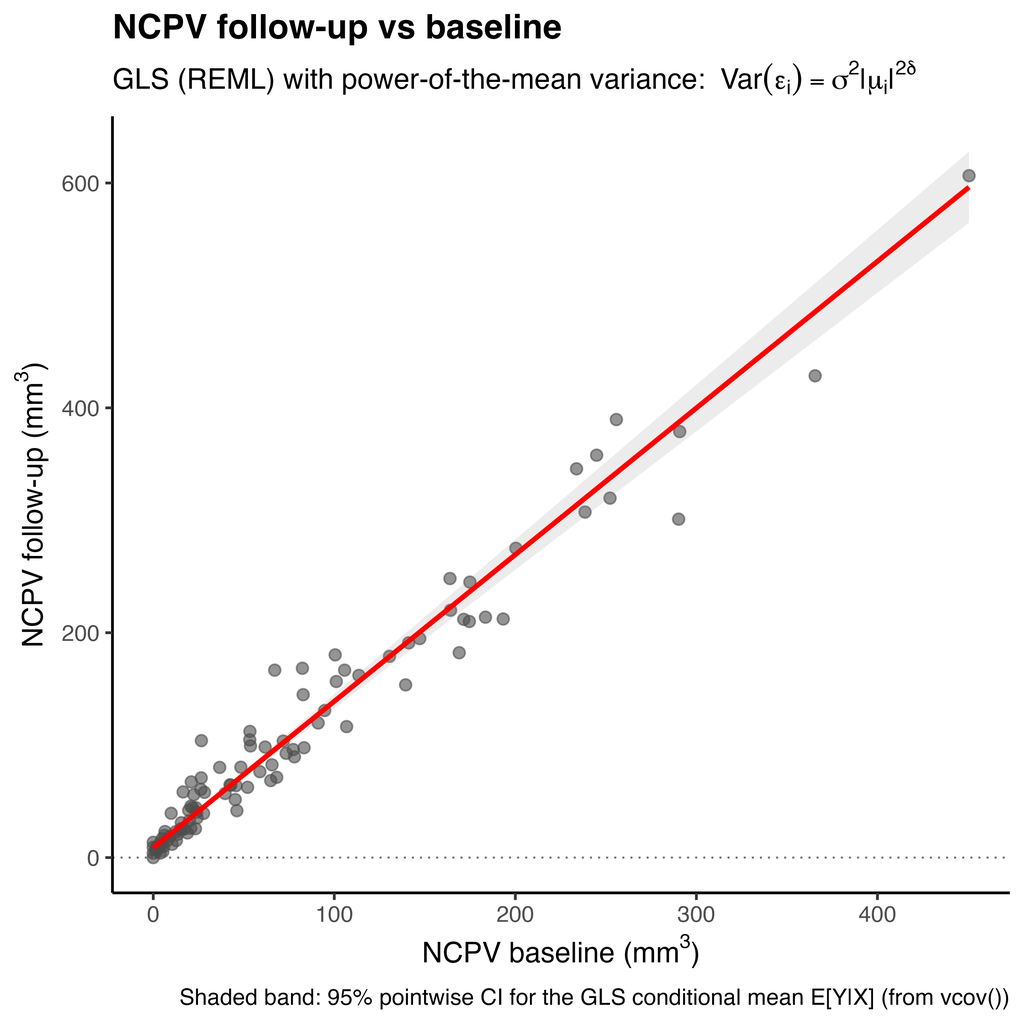

R² (baseline → follow-up, with linear mean): Baseline alone explains ≈ 96% of the variation (GLS weighted “R²” ≈ 93%) in follow-up values. Only ~4% (or 7%) is left after accounting for baseline.

ICC = Intraclass Correlation Coefficient — Proportion of total variance due to differences between people (vs within-person change).

ICC ≈ 0.91: about 91% of variability is between individuals; within-person year-to-year change is small.

This is Autocorrelation, more specifically **serial (auto)correlation, or within-person persistence**, not insight. Baseline plaque “predicts” follow-up mainly because the measure is relatively stable over time (high R², high ICC).

If we use baseline-adjusted regression, we could answer the question: “What explains the extra change beyond baseline?”

baseline-adjusted model (ANCOVA):

`Follow-up ~ Baseline + ApoB (+ covariates)`

– Test ApoB’s incremental value (partial F-test / ΔR²)

– still need to check model assumptions

Effect modification check:

`Follow-up ~ Baseline + ApoB + (+ covariates) + Baseline*ApoB`

– If the interaction is non-significant, ApoB’s association with follow-up does not depend on baseline level.